# Machine Learning Course Project

Coursera - Practical Machine Learning

Scott A. Smith

Sunday, January 18, 2015

### Introduction

Researchers in Brazil applied sensors to practitioners of a dumbbell curl. The practitioners were instructed to perform the exercise correctly and in four specific improper methods. Data was collected for the exercises in five classifications.

### Objective

Use collected data to classify observations into five classes.

### Implementation

##### Load R Packages & Data

```r
library(caret); library(ggplot2); library(RCurl)
data1 <- getURL("https://d396qusza40orc.cloudfront.net/predmachlearn/pml-training.csv",
                ssl.verifypeer=0L, followlocation=1L)
data2 <- getURL("https://d396qusza40orc.cloudfront.net/predmachlearn/pml-testing.csv",
                ssl.verifypeer=0L, followlocation=1L)
writeLines(data1,"pml-training.csv")
writeLines(data2,"pml-testing.csv")
training <- read.csv("pml-training.csv",as.is=TRUE)
testing <- read.csv("pml-testing.csv",as.is=TRUE)
```

##### Clean Up Data

```r
# Correct a spelling error in the imported data column names
names(training)[names(training)=="kurtosis_picth_belt"]<-"kurtosis_pitch_belt"
names(testing)[names(testing)=="kurtosis_picth_belt"]<-"kurtosis_pitch_belt"

# Convert the training data set classification to a factor
training$classe <- as.factor(training$classe)
```

##### Feature Selection

Feature selection was performed manually by visual investigation of the data. The approach was intuitive and used the featurePlot function to plot 5-8 pairs at a time traversing through the complete variable space.

The plot below shows that cross-plotting belt pitch against belt yaw, colored by classe to visually show class groupings.

This process resulted in use of the following seven factors. 1. pitch_belt 2. yaw_belt 3. total_accel_belt 4. total_accel_arm 5. total_accel_dumbbell 6. roll_forearm 7. yaw_forearm

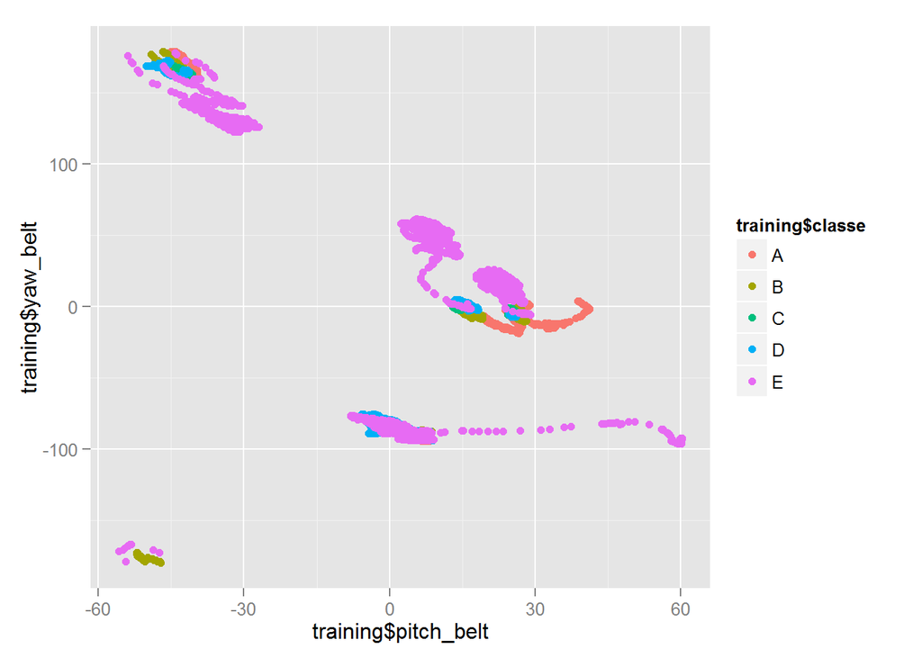

##### Configure Model Training Parameters

K-Fold Cross-Validation was applied using the trainControl() function with 10 folds.

```r
gbmCtrl <- trainControl(method = "cv",
                        number = 10,
                        classProbs = TRUE)
```

##### Model Training

The caret Generalized Boosting Model (gbm) was used to develop the classification model. The number of trees and shrinkage in the gbm model impact out-of-sample error, where specifically shrinkage (or learning rate) is positively related to out-of-sample error. Smaller values of shrinkage result in decreased out-of-sample error, but significantly increased computational complexity.

```r
set.seed(137)
gbmFit <- train(classe ~ pitch_belt+yaw_belt+total_accel_belt+total_accel_arm+total_accel_dumbbell+roll_forearm+yaw_forearm,
                data = training,
                method = "gbm",
                trControl = gbmCtrl,
                metric = "ROC",
                verbose = FALSE)
```

##### Model Analysis

The output below indicates a model accuracy of 89% for the training set. Positive and negative predictive values for Class A of 94% and 97% respectively are very good in that this is the “correct” approach to the excercise. Discrimination of the correct class is important in deciding whether to provide corrective guidance to the practitioner.

```r
gbmTrnClasses <- predict(gbmFit,newdata=training)
gbmTrnProbs <- predict(gbmFit,newdata=training,type="prob")
confusionMatrix(gbmTrnClasses,training$classe)
```

```
## Confusion Matrix and Statistics
##
##           Reference
## Prediction    A    B    C    D    E
##          A 5126  203   36   87   27
##          B  190 3168  207   32  126
##          C  165  268 2981  164  107
##          D   92   62  178 2905   56
##          E    7   96   20   28 3291
##
## Overall Statistics
##
##                Accuracy : 0.8904
##                  95% CI : (0.8859, 0.8947)
##     No Information Rate : 0.2844
##     P-Value [Acc > NIR] : < 2.2e-16
##
##                   Kappa : 0.8615
##  Mcnemar's Test P-Value : < 2.2e-16
##
## Statistics by Class:
##
##                      Class: A Class: B Class: C Class: D Class: E
## Sensitivity            0.9186   0.8343   0.8711   0.9033   0.9124
## Specificity            0.9749   0.9649   0.9565   0.9764   0.9906
## Pos Pred Value         0.9356   0.8509   0.8090   0.8822   0.9561
## Neg Pred Value         0.9679   0.9604   0.9723   0.9810   0.9805
## Prevalence             0.2844   0.1935   0.1744   0.1639   0.1838
## Detection Rate         0.2612   0.1615   0.1519   0.1480   0.1677
## Detection Prevalence   0.2792   0.1897   0.1878   0.1678   0.1754
## Balanced Accuracy      0.9467   0.8996   0.9138   0.9398   0.9515
```

##### Conclusion & Discussion

The developed model showed an overall accuracy of 89% and did very well at discriminating between the five exercise classes.

##### Follow-up

The model was based on seven factors and the relative importances are plotted below. The top two and fourth items all are outputs from the belt sensor. The application of this technology may be simplified significantly by using one sensor on the belt. Additional modeling work is warranted to investigate achievable accuracy using one belt sensor.

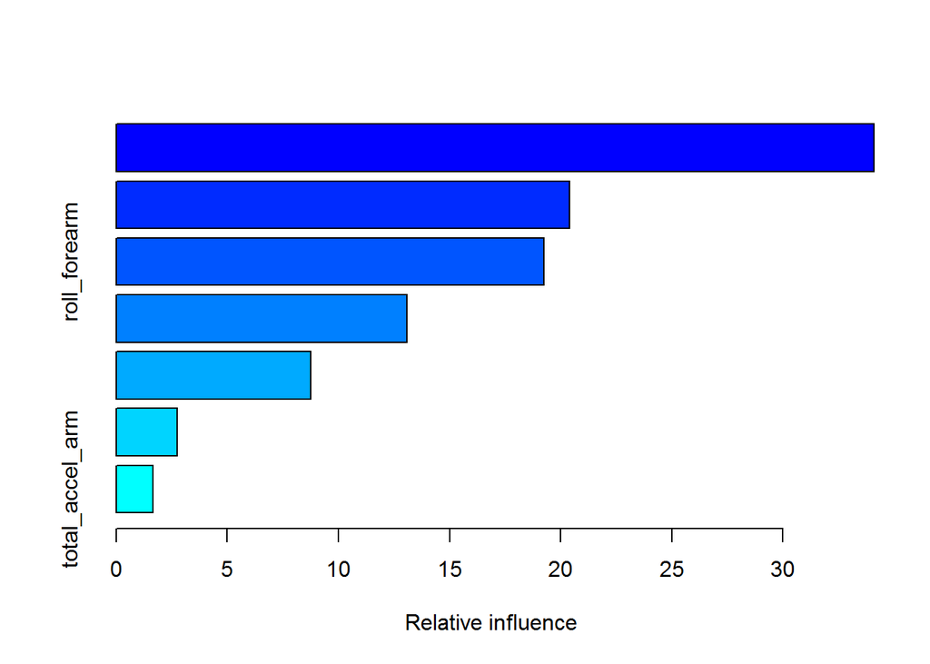

```
##                                       var   rel.inf
## yaw_belt                         yaw_belt 34.102289
## pitch_belt                     pitch_belt 20.393543
## roll_forearm                 roll_forearm 19.262280
## total_accel_belt         total_accel_belt 13.078510
## total_accel_dumbbell total_accel_dumbbell  8.760405
## yaw_forearm                   yaw_forearm  2.753178
## total_accel_arm           total_accel_arm  1.649795
```

### Resources

[1] Velloso, E.; Bulling, A.; Gellersen, H.; Ugulino, W.; Fuks, H. Qualitative Activity Recognition of Weight Lifting Exercises. Proceedings of 4th International Conference in Cooperation with SIGCHI (Augmented Human ’13) . Stuttgart, Germany: ACM SIGCHI, 2013. http://groupware.les.inf.puc-rio.br/har